# 542_Final

Brittany Dymond, Hailey Fagerness, Cecilia Liang, Kathy Wang

3/16/2020

# Fossil Fuels & Economic Development

## Rationale of our two questions

How do fossil fuels relate to social and economic development in different countries? * Can we identify groups of countries with similar oil production and GDP and if/how oil production impacts a country’s GDP? * Can we identify groups of countries with similar population and fossil fuel usage and if/how population size affects fossil fuel usage?

Data: * Population * GDP per Capita * Oil Production (92 countries) * Fossil fuel use (as % of total electricity generating capacity)

## *QUESTION 1 CLUSTERING CODE START*

RESEARCH QUESTION: ‘Can we identify groups of countries with similar oil production and GDP and if/how oil production impacts a country’s GDP?’

Data used: * Oil Production: [from U.S. Energy Information Administration] For calendar year 2019, on a comparable best-estimate basis * GDP per Capita: [from Wikipedia] Converted at market exchange rates to current U.S. dollars, divided by the population for the same year

Prep to cluster OilProduction and GDP_pc Getting data from github and initializing：

Removing rows where OilProduction == 0：

### Clustering Part

Preparing to cluster oil production & GDP：

```
##           OilProduction GDP_pc
## Albania           22915   5372
## Algeria         1348361   3980
## Angola          1769615   3037
## Argentina        510560   9887
## Australia        289749  53825
## Austria           15161  50022
```

This is for replicability of results.

### Partitioning Technique: PAM

1. Apply function and indicate the amount of clusters required
2. Clustering results

TABLE OF CLUSTERS：

```
##
##  1  2  3  4
## 58 14 17  3
```

3. Evaluate Results

AVG SILHOUETTES：

```
##   cluster size ave.sil.width
## 1       1   58          0.58
## 2       2   14          0.41
## 3       3   17          0.52
## 4       4    3          0.30
```

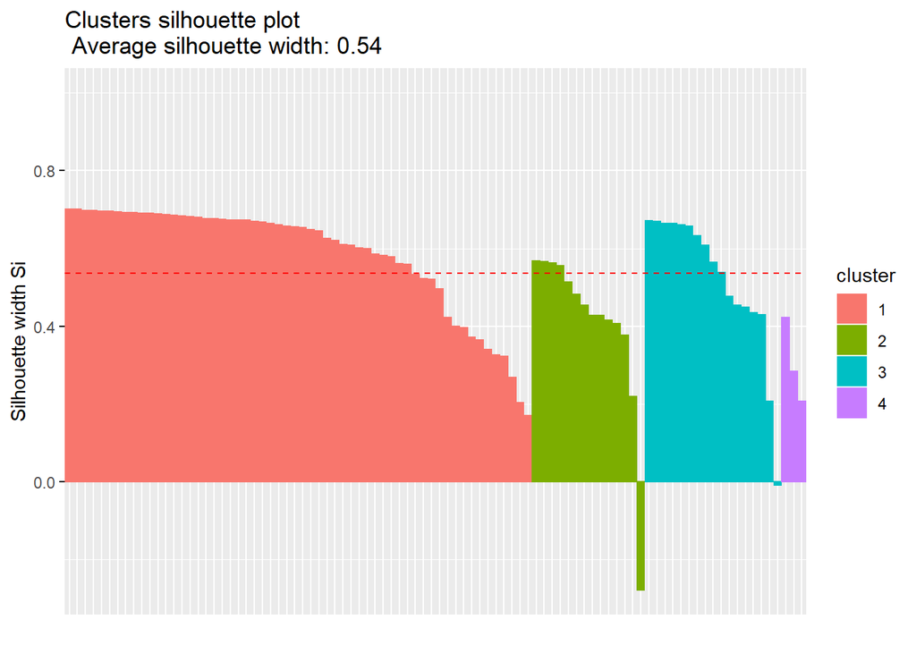

DECTECTING ANOMALIES：

```
##                        cluster neighbor sil_width
## Vietnam                      1        3 0.7014283
## Congo, Republic of the       1        3 0.7006665
## Papua New Guinea             1        3 0.6977134
## Ghana                        1        3 0.6972409
## Timor-Leste                  1        3 0.6957549
## Tunisia                      1        3 0.6955229
```

Requesting negative silhouettes：

```
##         cluster neighbor    sil_width
## Italy         2        3 -0.277837863
## Romania       3        1 -0.008107932
```

### Hierarchizing/Agglomerative Technique: AGNES

1. Apply function and indicate the amount of clusters required
2. Clustering results

TABLE OF CLUSTERS:

```
##
##  1  2  3  4
## 59 14 16  3
```

3. Evaluate results

DENDOGRAM:

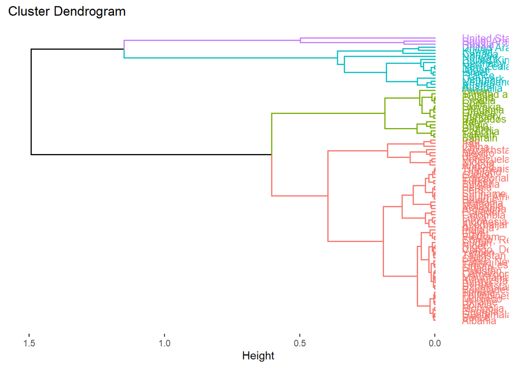

AVG SILHOUETTES:

```
##   cluster size ave.sil.width
## 1       1   59          0.57
## 2       2   14          0.35
## 3       3   16          0.60
## 4       4    3          0.30
```

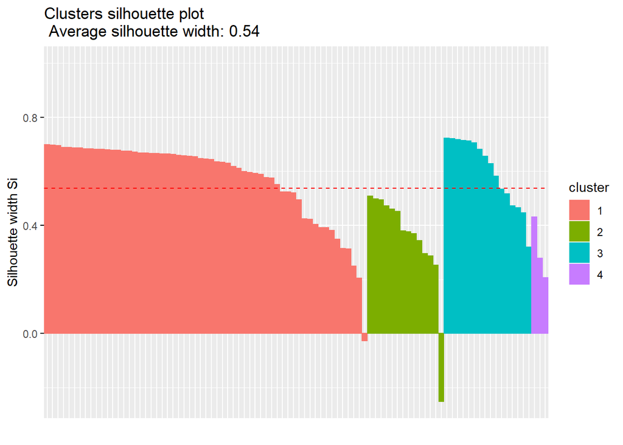

DECTECTING ANOMALIES:

```
##                        cluster neighbor sil_width
## Vietnam                      1        3 0.6977023
## Congo, Republic of the       1        3 0.6970225
## Egypt                        1        3 0.6946234
## Ghana                        1        3 0.6884544
## Papua New Guinea             1        3 0.6880476
## Timor-Leste                  1        3 0.6860947
```

Requesting negative silhouettes:

```
##         cluster neighbor   sil_width
## Romania       1        3 -0.02769694
## Kuwait        2        3 -0.25164833
```

### Hierarchizing/Divisive Technique: DIANA

1. Apply function and indicate the amount of clusters required
2. Clustering results

TABLE OF CLUSTERS:

```
##
##  1  2  3  4
## 72 17  2  1
```

3. Evaluate results

DENDOGRAM:

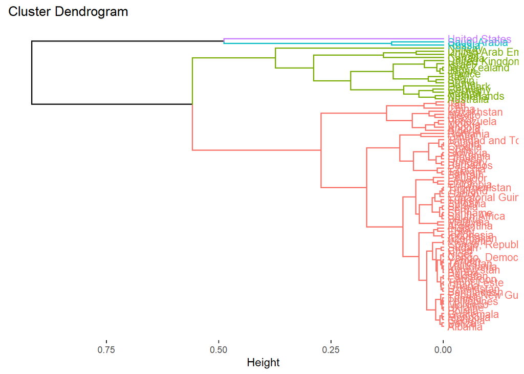

AVG SILHOUETTES:

```
##   cluster size ave.sil.width
## 1       1   72          0.72
## 2       2   17          0.50
## 3       3    2          0.70
## 4       4    1          0.00
```

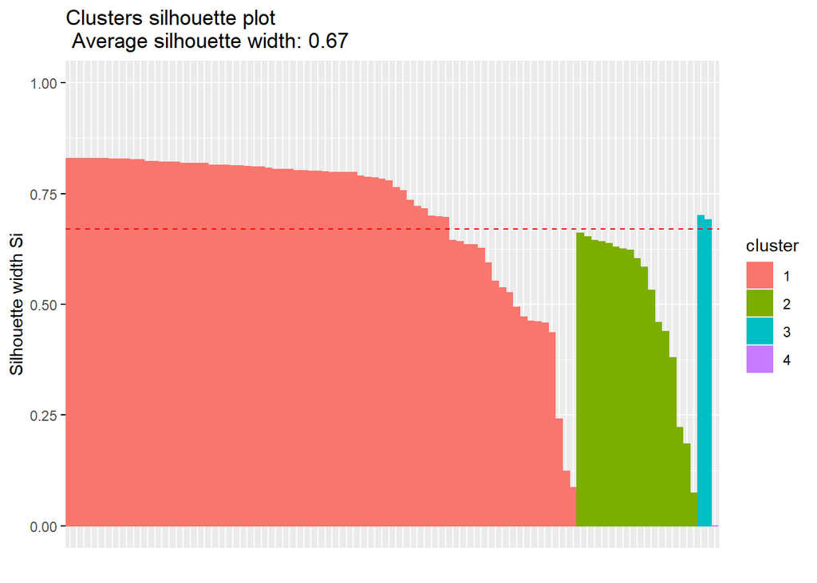

DECTECTING ANOMALIES:

```
##           cluster neighbor sil_width
## Mongolia        1        2 0.8295996
## Bolivia         1        2 0.8294036
## Ukraine         1        2 0.8291026
## Guatemala       1        2 0.8285038
## Tunisia         1        2 0.8284611
## Georgia         1        2 0.8284214
```

Requesting negative silhouettes:

```
## [1] cluster   neighbor  sil_width
## <0 rows> (or 0-length row.names)
```

### Density Based Clustering: DBSCAN

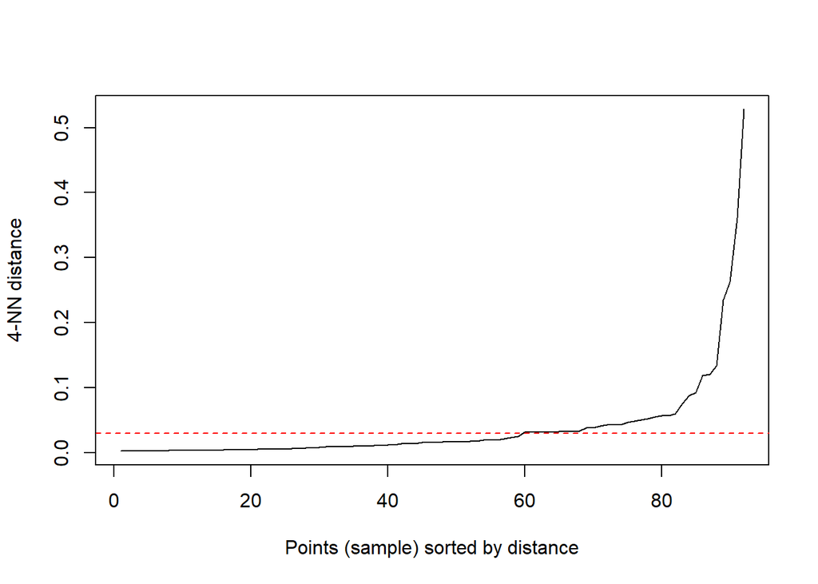

```
## DBSCAN clustering for 92 objects.
## Parameters: eps = 0.03, minPts = 4
## The clustering contains 3 cluster(s) and 20 noise points.
##
##  0  1  2  3
## 20 53 14  5
##
## Available fields: cluster, eps, minPts
```

Save coordinates to original data frame:

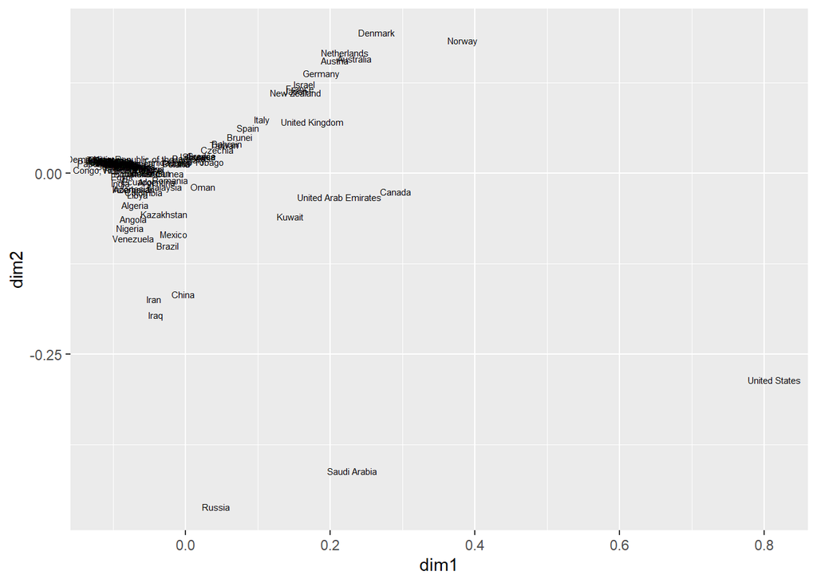

- Plot PAM：
- Plot AGNES：
- Plot DIANA：

Compare results visually：

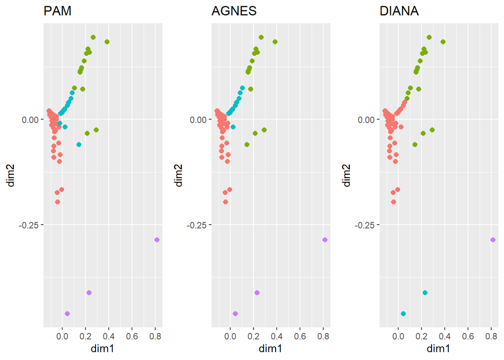

- Plot DBSCAN：

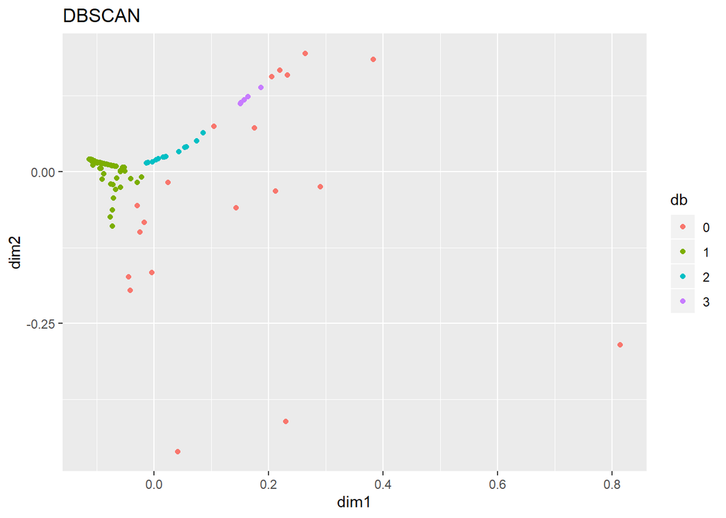

Annotating:

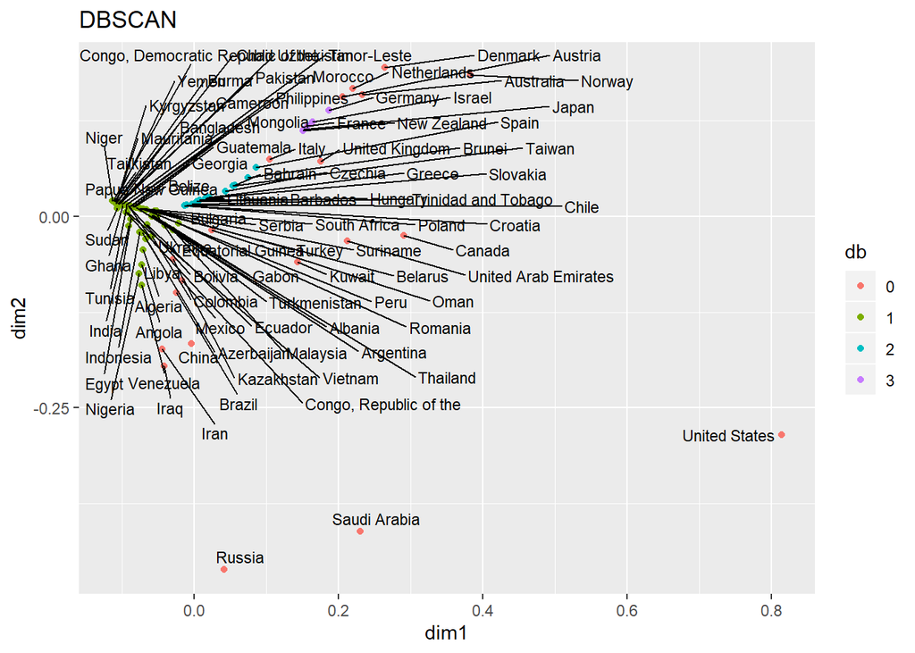

Annotating Outliers:

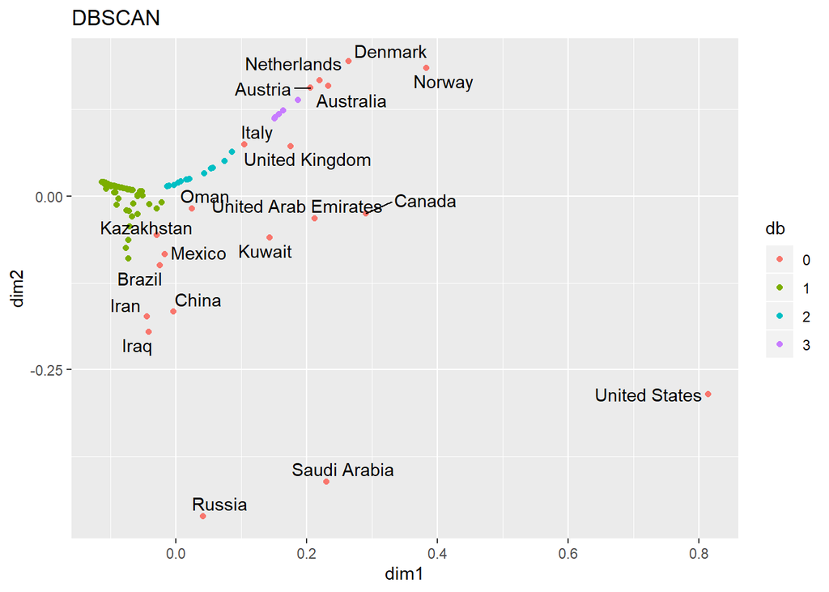

BASED ON CLUSTERING, WE WILL USE DBSCAN. This cluster had high production &/OR high GDP (outliers).

```
##  [1] "Australia"            "Austria"              "Brazil"
##  [4] "Canada"               "China"                "Denmark"
##  [7] "Iran"                 "Iraq"                 "Italy"
## [10] "Kazakhstan"           "Kuwait"               "Mexico"
## [13] "Netherlands"          "Norway"               "Oman"
## [16] "Russia"               "Saudi Arabia"         "United Arab Emirates"
## [19] "United Kingdom"       "United States"
```

This cluster had higher production & lower GDP.

```
##  [1] "Albania"                           "Algeria"
##  [3] "Angola"                            "Argentina"
##  [5] "Azerbaijan"                        "Bangladesh"
##  [7] "Belarus"                           "Belize"
##  [9] "Bolivia"                           "Bulgaria"
## [11] "Burma"                             "Cameroon"
## [13] "Chad"                              "Colombia"
## [15] "Congo, Democratic Republic of the" "Congo, Republic of the"
## [17] "Ecuador"                           "Egypt"
## [19] "Equatorial Guinea"                 "Gabon"
## [21] "Georgia"                           "Ghana"
## [23] "Guatemala"                         "India"
## [25] "Indonesia"                         "Kyrgyzstan"
## [27] "Libya"                             "Malaysia"
## [29] "Mauritania"                        "Mongolia"
## [31] "Morocco"                           "Niger"
## [33] "Nigeria"                           "Pakistan"
## [35] "Papua New Guinea"                  "Peru"
## [37] "Philippines"                       "Romania"
## [39] "Serbia"                            "South Africa"
## [41] "Sudan"                             "Suriname"
## [43] "Tajikistan"                        "Thailand"
## [45] "Timor-Leste"                       "Tunisia"
## [47] "Turkey"                            "Turkmenistan"
## [49] "Ukraine"                           "Uzbekistan"
## [51] "Venezuela"                         "Vietnam"
## [53] "Yemen"
```

This cluster had lower production & lower GDP.

```
##  [1] "Bahrain"             "Barbados"            "Brunei"
##  [4] "Chile"               "Croatia"             "Czechia"
##  [7] "Greece"              "Hungary"             "Lithuania"
## [10] "Poland"              "Slovakia"            "Spain"
## [13] "Taiwan"              "Trinidad and Tobago"
```

This cluster had lower production & higher GDP.

```
## [1] "France"      "Germany"     "Israel"      "Japan"       "New Zealand"
```

## *QUESTION 1 REGRESSION START*

- Hypothesis:
  - Model 1: GDP Per Capita ~ Oil Production
  - Model 2: GDP Per Capita ~ Oil Production + Continent
- Continuous Outcome – – GDP Per Capita
- Independent variable – – Oil Production
- Control variable – – Continent
- Rationale for hypothesis
  - Oil infrastructure supports GDP
  - OPEC // many economies heavily rely on oil income
  - Oil price wars (like now with Saudi Arabia and Russia) impact oil prices and thus GDP

Preparing to regress Oil Production & GDP

```
## 'data.frame':    92 obs. of  12 variables:
##  $ Country                : chr  "Albania" "Algeria" "Angola" "Arge"..
##  $ fossilFuel_PctTotalElec: num  0.05 0.96 0.34 0.69 0.72 0.25 0.84 ..
##  $ OilProduction          : num  22915 1348361 1769615 510560 289749..
##  $ Population             : int  2880917 43053054 31825295 44780677 ..
##  $ GDP_pc                 : int  5372 3980 3037 9887 53825 50022 468..
##  $ Continent              : Factor w/ 7 levels "Africa","Asia",..: 3..
##  $ pam                    : Factor w/ 4 levels "1","2","3","4": 1 1 ..
##  $ agn                    : Factor w/ 4 levels "1","2","3","4": 1 1 ..
##  $ dia                    : Factor w/ 4 levels "1","2","3","4": 1 1 ..
##  $ db                     : Factor w/ 4 levels "0","1","2","3": 2 2 ..
##  $ dim1                   : num  -0.0795 -0.0701 -0.0722 -0.0399 0.2..
##  $ dim2                   : num  0.0111 -0.0435 -0.063 -0.0116 0.159..
```

### EXPLANATORY APPROACH

1.State the hypotheses

```r
hypo1=formula(GDP_pc ~ OilProduction)
hypo2=formula(GDP_pc ~ OilProduction + Continent)
```

2.Save colums needed and varify data types

```
## 'data.frame':    92 obs. of  3 variables:
##  $ OilProduction: num  22915 1348361 1769615 510560 289749 ...
##  $ GDP_pc       : int  5372 3980 3037 9887 53825 50022 4689 25273 1905 18069 ...
##  $ Continent    : Factor w/ 7 levels "Africa","Asia",..: 3 1 1 7 6 3 4 2 2 5 ...
```

3.Compute regression models

4.Hypothesis results

- First Hypothesis:

```
##
## Call:
## glm(formula = hypo1, family = "gaussian", data = DataRegGauss)
##
## Deviance Residuals:
##    Min      1Q  Median      3Q     Max
## -20272  -11232   -7177    5968   61852
##
## Coefficients:
##                Estimate Std. Error t value Pr(>|t|)
## (Intercept)   1.337e+04  1.882e+03   7.103 2.76e-10 ***
## OilProduction 1.673e-03  7.318e-04   2.286   0.0246 *
## ---
## Signif. codes:  0 '***' 0.001 '**' 0.01 '*' 0.05 '.' 0.1 ' ' 1
##
## (Dispersion parameter for gaussian family taken to be 280755365)
##
##     Null deviance: 2.6736e+10  on 91  degrees of freedom
## Residual deviance: 2.5268e+10  on 90  degrees of freedom
## AIC: 2054.7
##
## Number of Fisher Scoring iterations: 2
```

- Second Hypothesis:

```r
summary(gauss2)
```

```
##
## Call:
## glm(formula = hypo2, family = "gaussian", data = DataRegGauss)
##
## Deviance Residuals:
##    Min      1Q  Median      3Q     Max
## -29507   -8171   -1380    5466   47217
##
## Coefficients:
##                          Estimate Std. Error t value Pr(>|t|)
## (Intercept)             2.227e+03  3.288e+03   0.677 0.500143
## OilProduction           2.140e-03  6.498e-04   3.294 0.001448 **
## ContinentAsia           7.450e+03  4.231e+03   1.761 0.081897 .
## ContinentEurope         2.500e+04  4.421e+03   5.656 2.09e-07 ***
## ContinentEurope/Asia   -2.640e+02  7.171e+03  -0.037 0.970725
## ContinentNorth America  1.499e+04  6.409e+03   2.340 0.021675 *
## ContinentOceania        2.990e+04  8.669e+03   3.449 0.000882 ***
## ContinentSouth America  3.519e+03  5.678e+03   0.620 0.537102
## ---
## Signif. codes:  0 '***' 0.001 '**' 0.01 '*' 0.05 '.' 0.1 ' ' 1
##
## (Dispersion parameter for gaussian family taken to be 193147596)
##
##     Null deviance: 2.6736e+10  on 91  degrees of freedom
## Residual deviance: 1.6224e+10  on 84  degrees of freedom
## AIC: 2026
##
## Number of Fisher Scoring iterations: 2
```

5.Searching for a better model

```
## Analysis of Deviance Table
##
## Model 1: GDP_pc ~ OilProduction
## Model 2: GDP_pc ~ OilProduction + Continent
##   Resid. Df Resid. Dev Df   Deviance Pr(>Chi)
## 1        90 2.5268e+10
## 2        84 1.6224e+10  6 9043584826 2.03e-08 ***
## ---
## Signif. codes:  0 '***' 0.001 '**' 0.01 '*' 0.05 '.' 0.1 ' ' 1
```

Model for the Second hypothesis is chosen. This is the RSquared:

```
## [1] 0.3425815
```

6.Verify the situation of chosen model:

6.1. Linearity between dependent variable and predictors is assumed, then these dots should follow a linear and horizontal trend:

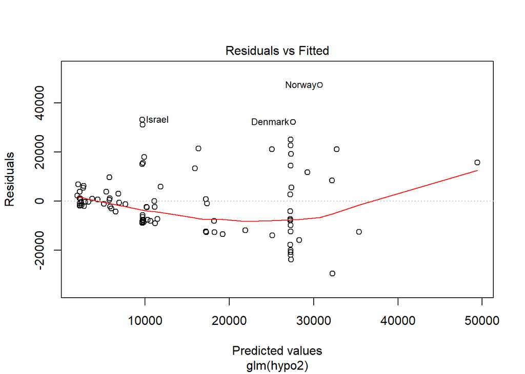

The linear trend is not obvious, and the distribution range goes wider when the predicted values increase. I’d like to say it represents the linearity between our variables in a certain level. Further research upon outliers are necessary.

6.2. Normality of residuals is assumed:

Visual exploration

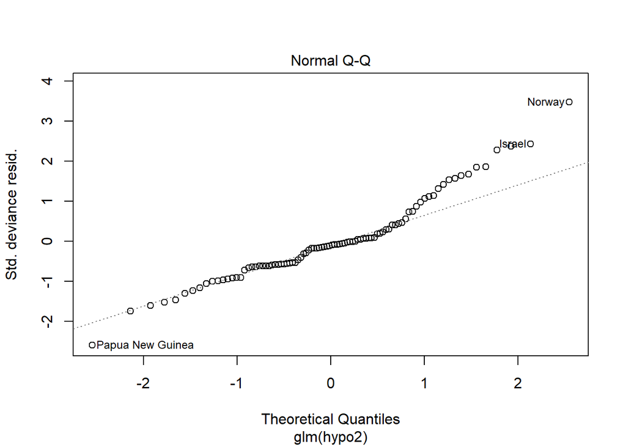

Mathematical exploration:

```
##
##  Shapiro-Wilk normality test
##
## data:  gauss2$residuals
## W = 0.94464, p-value = 0.000681
```

6.3. Homoscedasticity is assumed, so check if residuals are spread equally along the ranges of predictors

Visual exploration:

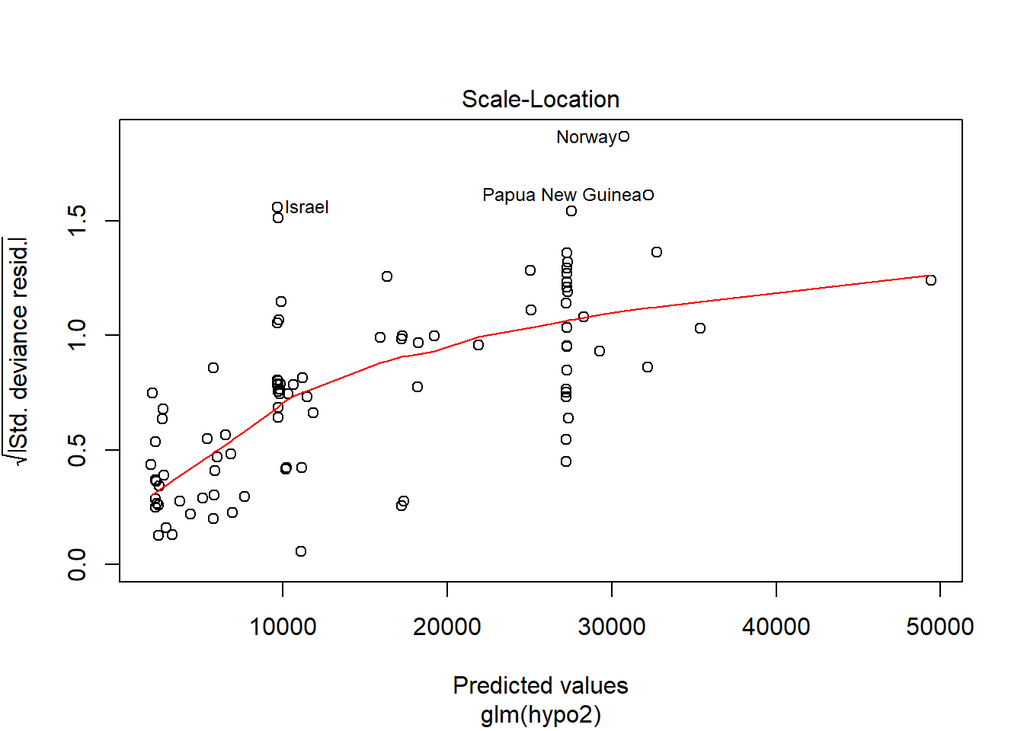

Mathematical exploration:

```
##
##  studentized Breusch-Pagan test
##
## data:  gauss2
## BP = 19.735, df = 7, p-value = 0.006171
```

6.4. We assume that there is no colinearity, that is, that the predictors are not correlated.

```
##                   GVIF Df GVIF^(1/(2*Df))
## OilProduction 1.146212  1        1.070613
## Continent     1.146212  6        1.011437
```

6.5. Analize the effect of atypical values. Determine if outliers (points that are far from the rest, but still in the trend) or high-leverage points (far from the trend but close to the rest) are influential

Visual exploration:

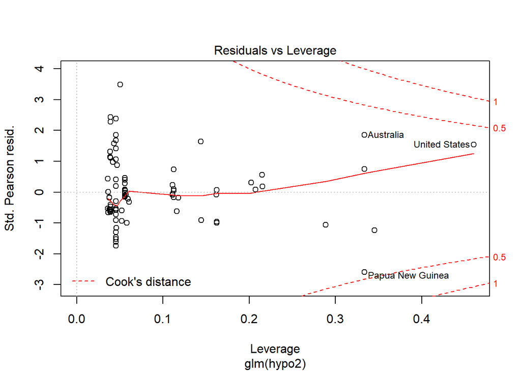

Querying:

```r
gaussInf=as.data.frame(influence.measures(gauss2)$is.inf)
gaussInf[gaussInf$cook.d,]
```

```
##  [1] dfb.1_   dfb.OlPr dfb.CntA dfb.CntE dfb.CE/A dfb.CnNA dfb.CntO dfb.CnSA
##  [9] dffit    cov.r    cook.d   hat
## <0 rows> (or 0-length row.names)
```

7. Finally, a nice summary plot of our work

```
## Learn more about sjPlot with 'browseVignettes("sjPlot")'.
```

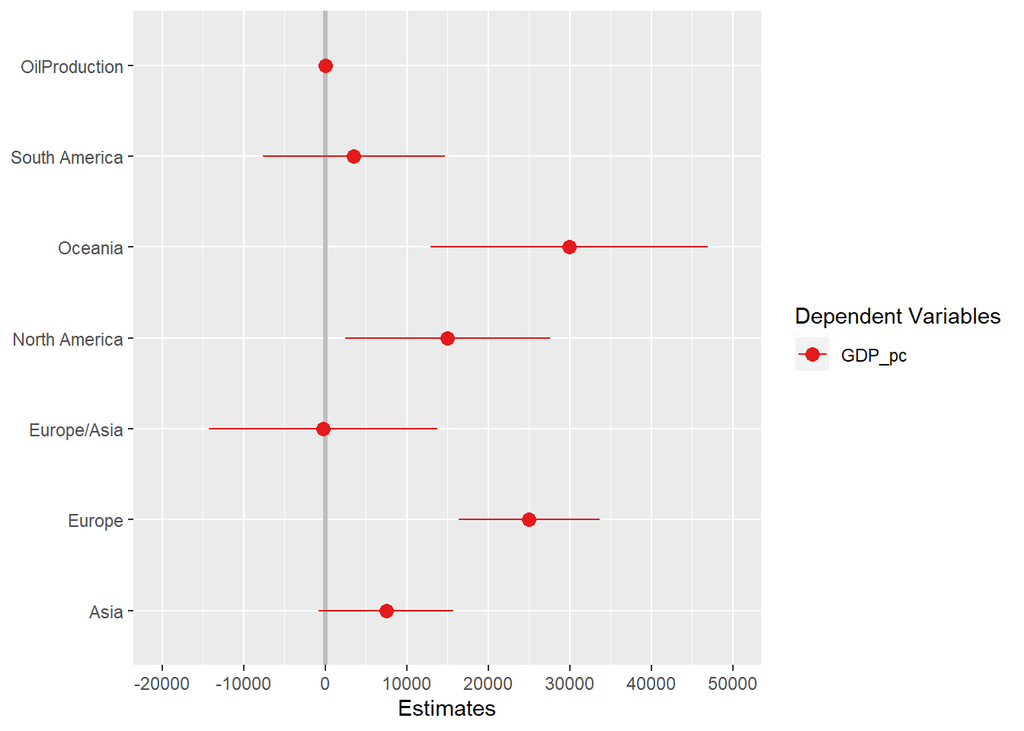

### PREDICTIVE APPROACH

1. Splitting the data set
2. Regress with train data

```
##
## Call:
## NULL
##
## Deviance Residuals:
##    Min      1Q  Median      3Q     Max
## -29470   -9388   -1480    7635   44909
##
## Coefficients:
##                            Estimate Std. Error t value Pr(>|t|)
## (Intercept)               2.204e+03  4.180e+03   0.527  0.59982
## OilProduction             2.670e-03  8.371e-04   3.189  0.00221 **
## ContinentAsia             8.393e+03  5.127e+03   1.637  0.10657
## ContinentEurope           2.646e+04  5.685e+03   4.655 1.68e-05 ***
## `ContinentEurope/Asia`   -1.646e+03  8.083e+03  -0.204  0.83925
## `ContinentNorth America`  1.532e+04  7.708e+03   1.988  0.05109 .
## ContinentOceania          2.986e+04  9.604e+03   3.109  0.00280 **
## `ContinentSouth America`  3.651e+03  7.890e+03   0.463  0.64509
## ---
## Signif. codes:  0 '***' 0.001 '**' 0.01 '*' 0.05 '.' 0.1 ' ' 1
##
## (Dispersion parameter for gaussian family taken to be 224537488)
##
##     Null deviance: 2.3585e+10  on 71  degrees of freedom
## Residual deviance: 1.4370e+10  on 64  degrees of freedom
## AIC: 1598.4
##
## Number of Fisher Scoring iterations: 2
```

3. Evaluate performance

```
##         RMSE     Rsquared          MAE
## 10322.575720     0.536489  7547.290591
```

## *QUESTION 2 CLUSTERING START*

RESEARCH QUESTION: ‘Can we identify groups of countries with similar population and fossil fuel usage and if/how population size affects fossil fuel usage?’

Data used: * fossilFuel_PctTotalElec: [from CIA World Factbook] percentage of total electricity generating capacity that comes from fossil fuels * Population: [UN Dept of Economic and Social Affairs] World population estimates

Prep to cluster fossilFuel_PctTotalElec and Population

```
##           fossilFuel_PctTotalElec Population
## Albania                      0.05    2880917
## Algeria                      0.96   43053054
## Angola                       0.34   31825295
## Argentina                    0.69   44780677
## Australia                    0.72   25203198
## Austria                      0.25    8955102
```

Set random seed for replicability of results:

Setting distance matrix:

Defining number of clusters for each method (NumCluster = 5) Clustering via pam method:

Adding pam results to original DF (DFnew1)

REPORT: Table of Cluster:

```
##
##  1  2  3  4  5
## 14 26 30 20  2
```

REPORT: Evaluate Results:

```
##   cluster size ave.sil.width
## 1       1   14          0.38
## 2       2   26          0.63
## 3       3   30          0.36
## 4       4   20          0.57
## 5       5    2          0.86
```

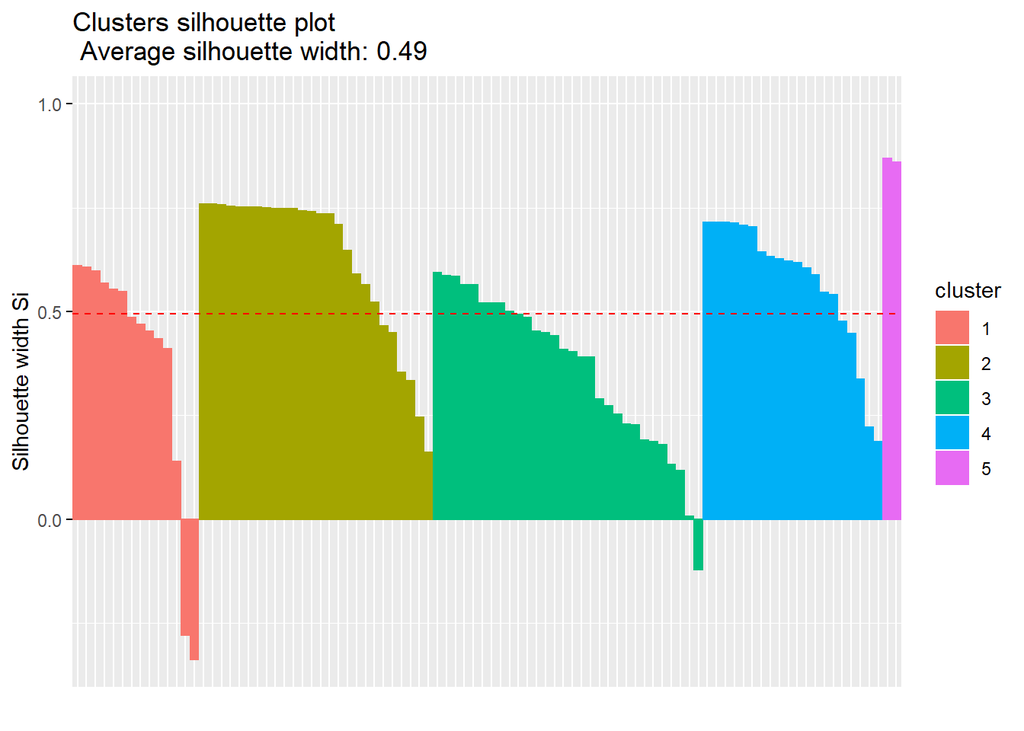

REPORT: Detecting Anomalies

Saving individual silhouettes

```
##                                   cluster neighbor sil_width
## Tajikistan                              1        4 0.6090716
## Albania                                 1        4 0.6060691
## Norway                                  1        4 0.5978116
## Timor-Leste                             1        4 0.5667970
## Congo, Democratic Republic of the       1        4 0.5525901
## France                                  1        4 0.5468275
```

Requesting negative silhouettes:

```
##         cluster neighbor  sil_width
## Angola        1        4 -0.2800818
## Georgia       1        4 -0.3377824
## Ghana         3        4 -0.1223473
```

Cluster via agnes method; indicate number of clusters (NumCluster):

Adding agn results to original DF (DFnew1)

REPORT: Table of clusters:

```
##
##  1  2  3  4  5
## 12 19 21 38  2
```

Evaluating results:

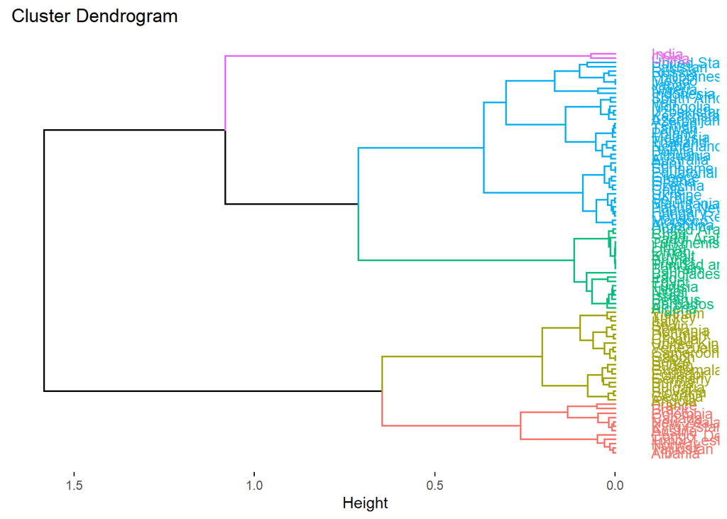

REPORT: Average silhouettes

```
##   cluster size ave.sil.width
## 1       1   12          0.47
## 2       2   19          0.79
## 3       3   21          0.60
## 4       4   38          0.23
## 5       5    2          0.87
```

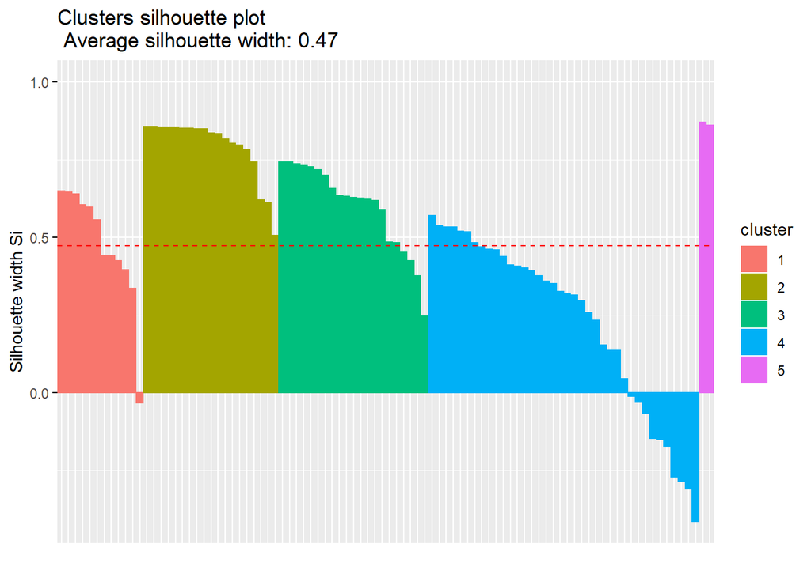

REPORT: Detecting anomalies

```
##                                   cluster neighbor sil_width
## Tajikistan                              1        3 0.6486823
## Albania                                 1        3 0.6461141
## Norway                                  1        3 0.6392016
## Timor-Leste                             1        3 0.6056001
## Congo, Democratic Republic of the       1        3 0.5963339
## France                                  1        3 0.5571241
```

Requesting negative silhouettes:

```
##              cluster neighbor   sil_width
## Colombia           1        3 -0.03279474
## Indonesia          4        2 -0.01212078
## Iran               4        2 -0.03057378
## Chile              4        3 -0.06866262
## Azerbaijan         4        2 -0.14697731
## South Africa       4        2 -0.15226216
## Ghana              4        3 -0.17299110
## Greece             4        3 -0.27237486
## Uzbekistan         4        2 -0.28525827
## Kazakhstan         4        2 -0.31159271
## Mongolia           4        2 -0.41514761
```

Cluster via diana method; indicate number of clusters (NumCluster):

Adding diana results to original DF (DFnew1):

REPORT: Table of clusters

```
##
##  1  2  3  4  5
## 12 26 23 29  2
```

REPORT: Dendrogram

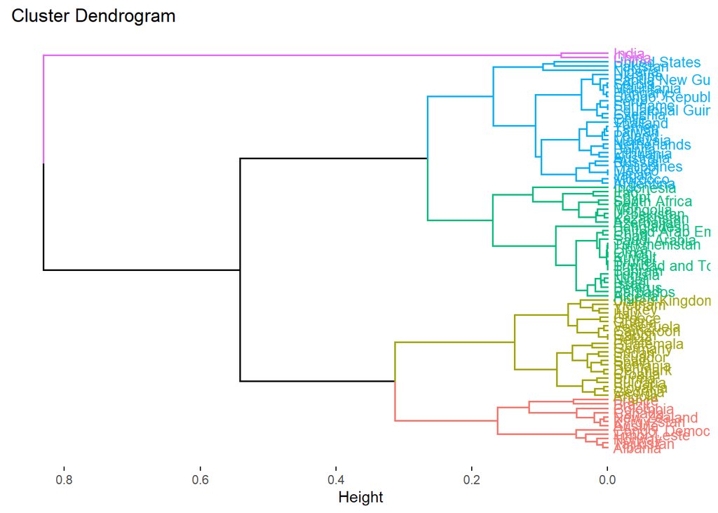

REPORT: Average silhouettes

```
##   cluster size ave.sil.width
## 1       1   12          0.49
## 2       2   26          0.62
## 3       3   23          0.52
## 4       4   29          0.39
## 5       5    2          0.86
```

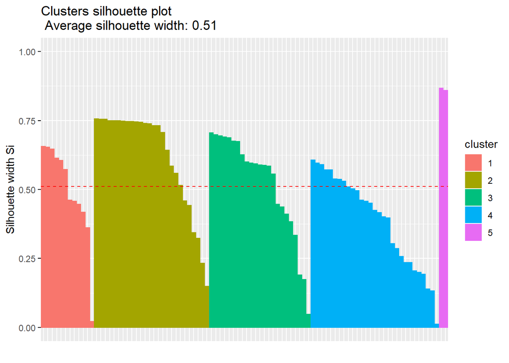

REPORT: Detecting anomalies:

```
##                                   cluster neighbor sil_width
## Tajikistan                              1        3 0.6564827
## Albania                                 1        3 0.6539019
## Norway                                  1        3 0.6467797
## Timor-Leste                             1        3 0.6133818
## Congo, Democratic Republic of the       1        3 0.6057145
## France                                  1        3 0.5720875
```

Requesting negative silhouettes:

```
## [1] cluster   neighbor  sil_width
## <0 rows> (or 0-length row.names)
```

Cluster via DBSCAN method; indicate minimum neighbors (4):

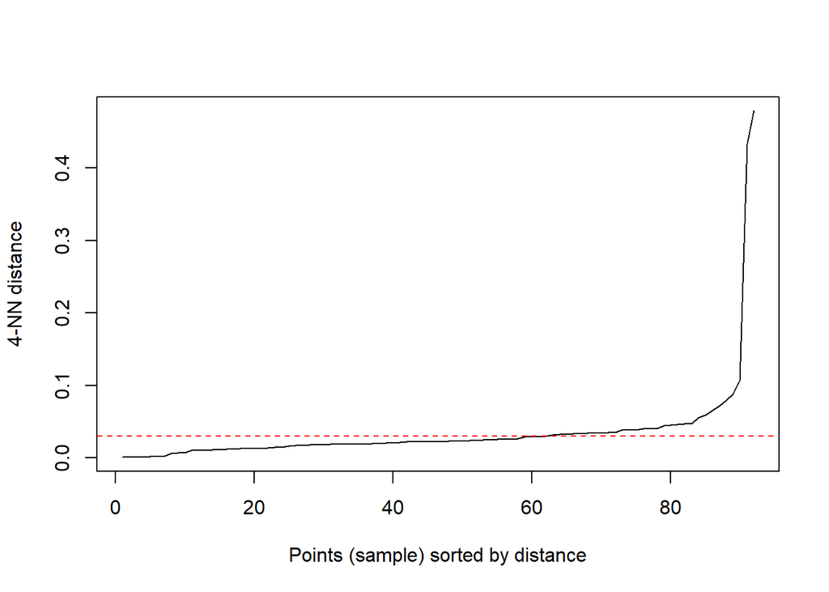

Setting distance (epsilon):

REPORT: Number of clusters and outliers produced

```
## DBSCAN clustering for 92 objects.
## Parameters: eps = 0.03, minPts = 4
## The clustering contains 4 cluster(s) and 11 noise points.
##
##  0  1  2  3  4
## 11  4 52  4 21
##
## Available fields: cluster, eps, minPts
```

Saving results:

Comparing clusters

Prepare a bidimensional map:

View bidimensional map:

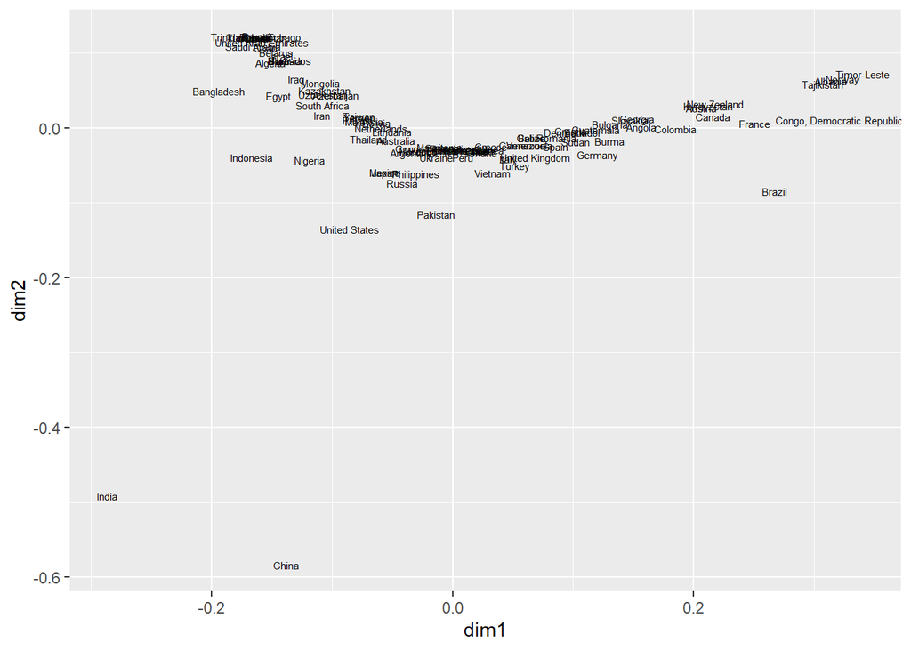

Results from pam:

Results from agnes:

Results from diana：

Compare visually:

Viewing pam, agnes, and diana plots side by side

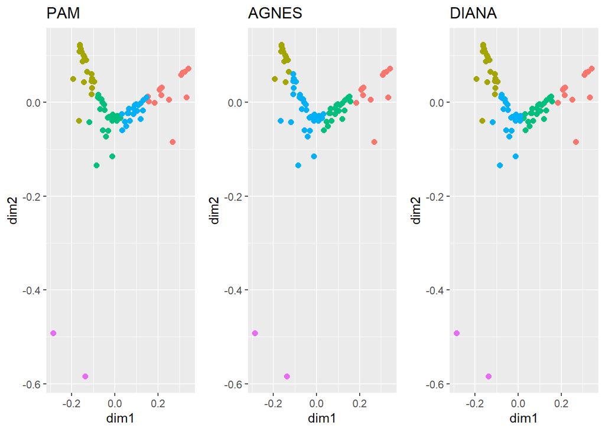

Plot results from DBSCAN：

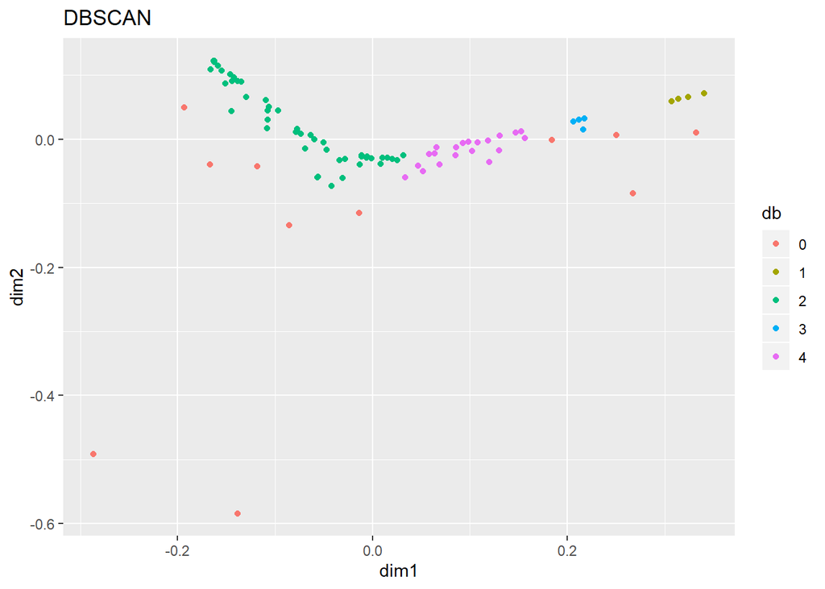

Annotating graph with country names：

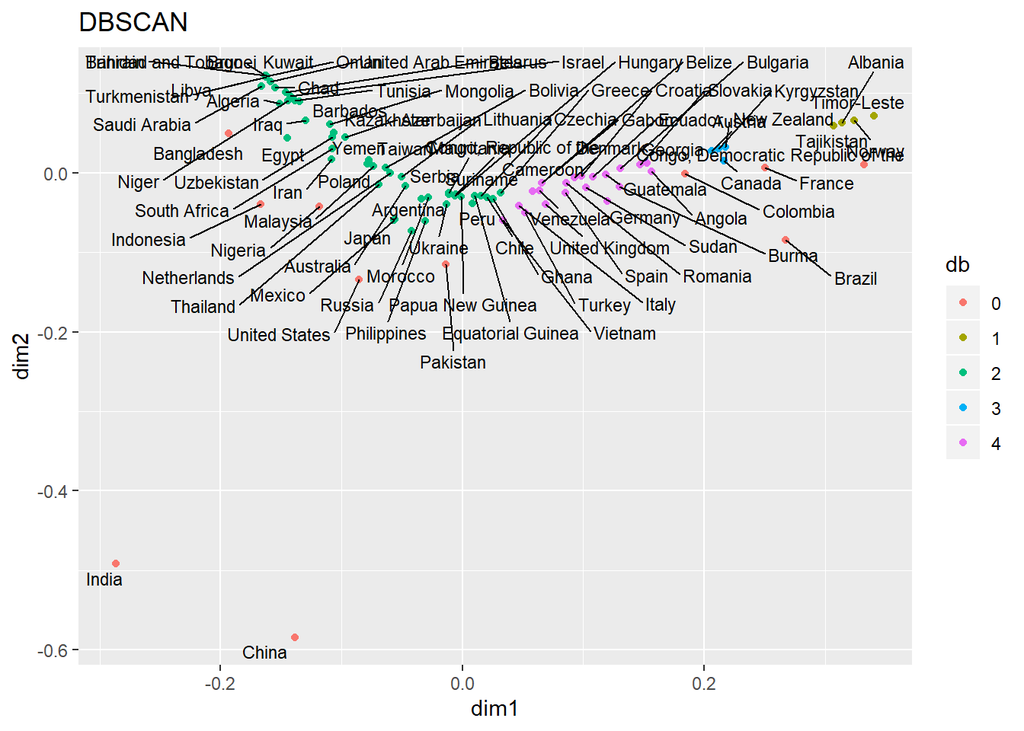

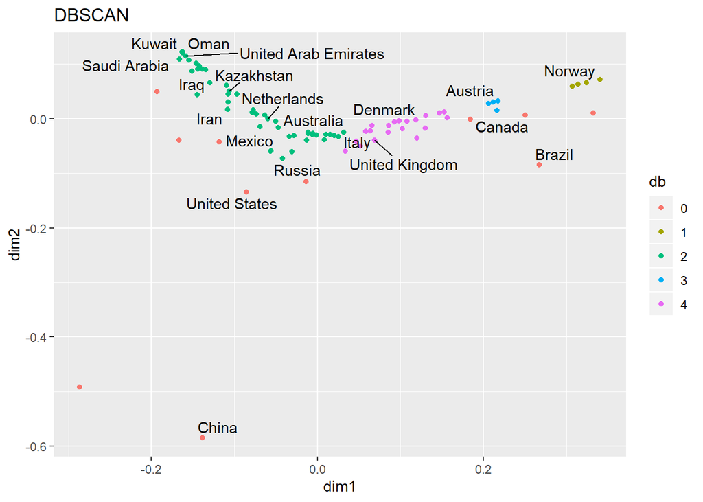

CHOOSING DIANA METHOD DUE TO HAVING ZERO NEGATIVE SILHOUETTES。

## *QUESTION 2 REGRESSION CODE START*

- Hypothesis:
  - Model 1: FF ~ Population
  - Model 2: FF ~ Population + Developed
- Method:
  - Binary Outcome – – FF usage (Median percentage FF use of total electricity capacity)
- Control variable – – Developed (Median GDP per capita)
- Independent variable – – Population
- Rationale for hypothesis:
  - Larger populations would exhibit higher fossil fuel usage as a percent of total electricity capacity

Changing dtype for population：

```
##                 Country fossilFuel_PctTotalElec           OilProduction
##             "character"               "numeric"               "numeric"
##              Population                  GDP_pc
##               "numeric"               "integer"
```

Changing dtype for GDP_pc(gdp):

```
##                 Country fossilFuel_PctTotalElec           OilProduction
##             "character"               "numeric"               "numeric"
##              Population                  GDP_pc
##               "numeric"               "numeric"
```

Filtering out non-oil producing countries & creating new DF (teamnew):

[output not shown]

[output cut: 171 more lines]

Converting USDollar to a factor variable

Calling new variable ‘Developed’

Converting fossilFuel_PctTotalElec to a factor variable

Calling new variable ‘FF’

Checking dtypes:

```
## 'data.frame':    92 obs. of  7 variables:
##  $ Country                : chr  "Albania" "Algeria" "Angola" "Arge"..
##  $ fossilFuel_PctTotalElec: num  0.05 0.96 0.34 0.69 0.72 0.25 0.84 ..
##  $ OilProduction          : num  22915 1348361 1769615 510560 289749..
##  $ Population             : num  2880917 43053054 31825295 44780677 ..
##  $ GDP_pc                 : num  5372 3980 3037 9887 53825 ...
##  $ Developed              : Factor w/ 2 levels "0","1": 1 1 1 2 2 2 ..
##  $ FF                     : Factor w/ 2 levels "0","1": 1 2 1 2 2 1 ..
```

Defining ‘Population’ as independent variable:

Defining columns needed：

Verify dtypes for colsNeededDico:

```
## 'data.frame':    92 obs. of  3 variables:
##  $ FF        : Factor w/ 2 levels "0","1": 1 2 1 2 2 1 2 2 2 2 ...
##  $ Population: num  2880917 43053054 31825295 44780677 25203198 ...
##  $ Developed : Factor w/ 2 levels "0","1": 1 1 1 2 2 2 1 2 1 2 ...
```

Create subset

Rename indexes by country

Define & compute regression models

Results of hypo3:

At p-value of 0.634, this model is not statistically significant

```
##
## Call:
## glm(formula = hypo3, family = "binomial", data = DataRegLogis)
##
## Deviance Residuals:
##    Min      1Q  Median      3Q     Max
## -1.436  -1.129  -1.126   1.223   1.230
##
## Coefficients:
##               Estimate Std. Error z value Pr(>|z|)
## (Intercept) -1.231e-01  2.217e-01  -0.555    0.579
## Population   4.972e-10  1.045e-09   0.476    0.634
##
## (Dispersion parameter for binomial family taken to be 1)
##
##     Null deviance: 127.37  on 91  degrees of freedom
## Residual deviance: 127.13  on 90  degrees of freedom
## AIC: 131.13
##
## Number of Fisher Scoring iterations: 4
```

Results of hypo4:

At p-values of 0.631 and 0.673, this model also is not statistically significant:

```
##
## Call:
## glm(formula = hypo4, family = "binomial", data = DataRegLogis)
##
## Deviance Residuals:
##    Min      1Q  Median      3Q     Max
## -1.479  -1.141  -1.089   1.192   1.268
##
## Coefficients:
##               Estimate Std. Error z value Pr(>|z|)
## (Intercept) -2.120e-01  3.063e-01  -0.692    0.489
## Population   5.028e-10  1.048e-09   0.480    0.631
## Developed1   1.768e-01  4.184e-01   0.422    0.673
##
## (Dispersion parameter for binomial family taken to be 1)
##
##     Null deviance: 127.37  on 91  degrees of freedom
## Residual deviance: 126.95  on 89  degrees of freedom
## AIC: 132.95
##
## Number of Fisher Scoring iterations: 4
```

Analysis of variance between models:

```
## Analysis of Deviance Table
##
## Model 1: FF ~ Population
## Model 2: FF ~ Population + Developed
##   Resid. Df Resid. Dev Df Deviance Pr(>Chi)
## 1        90     127.13
## 2        89     126.95  1  0.17869   0.6725
```

## Recommendations

### Second Question

Neither model is statistically significant; no further analysis required.

Recommendations for future analysis of question #2 include: *Incorporate country-specific income levels as an additional variable* Remove major outliers from sample population *Use actual fossil fuel usage data in lieu of ratios